# Validation set vs training set LDA training - Approach two CIFAR100

```r
library(ggplot2)
library(dplyr)
library(tidyr)
library("ggpubr")
```

This experiment focuses on the question, whether training LDA on the same set of data as the neural networks were trained on has any adverse effects to the performance of the ensemble as opposed to training on a different set, not presented to the networks during the training. Experiment was performed with two slightly different approaches.

Approach two Experiment code is in the file half_train_ensembling_experiment.py. Experiment on both CIFAR10 and CIFAR100 datasets. This experiment differs from the previous one in the neural networks training part. In this case, the networks were trained on half of the original training set. The remainder of the training set was extracted as a validation set. This enabled us to train several ensembles on both the training set and the validation set in each replication. Experiment on CIFAR10 was performed in 1 replication and experimennt on CIFAR100 in 10 replications. This is due to 10 times more classes in CIFAR100 and thus a need for 10 times larger LDA training set in order to maintain constant 50 samples for class in LDA models training.

Approach one is described in the file visualization_base_experiment.

# CIFAR100

```r
net_results <- read.csv("../data/data_train_val_half_c100/net_accuracies.csv")
ens_results <- read.csv("../data/data_train_val_half_c100/ensemble_accuracies.csv")
```

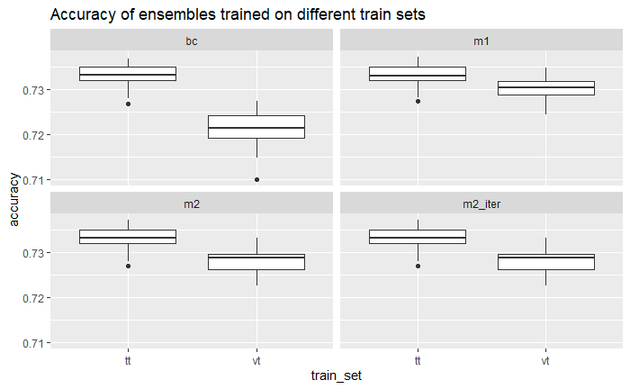

```r
box_acc <- ggplot() + geom_boxplot(data=ens_results, mapping = aes(x=train_set, y=accuracy)) + facet_wrap(~method) +
  ggtitle("Accuracy of ensembles trained on different train sets")
box_acc
```

Training on the same training data as the neural networks were trained on seems to provide better accuracy compared to training on separate validation set. This difference is bigger for bc coupling method, than for m1 and m2.

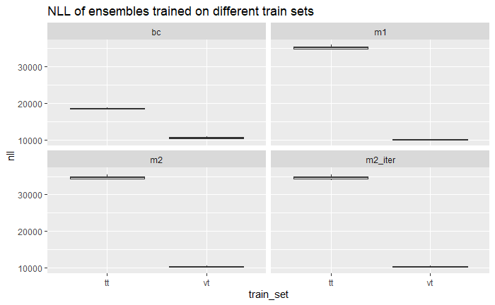

```r
box_nll <- ggplot() + geom_boxplot(data=ens_results, mapping = aes(x=train_set, y=nll)) + facet_wrap(~method) +
  ggtitle("NLL of ensembles trained on different train sets")
box_nll
```

For some reason NLL has opposite trend to accuracy - train set with better accuracy has worse (larger) NLL. This needs some further attention.

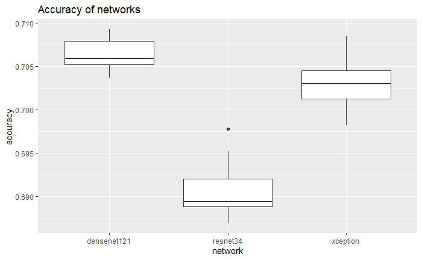

```r
box_net_acc <- ggplot() + geom_boxplot(data=net_results, mapping=aes(x=network, y=accuracy)) +
  ggtitle("Accuracy of networks")
box_net_acc
```

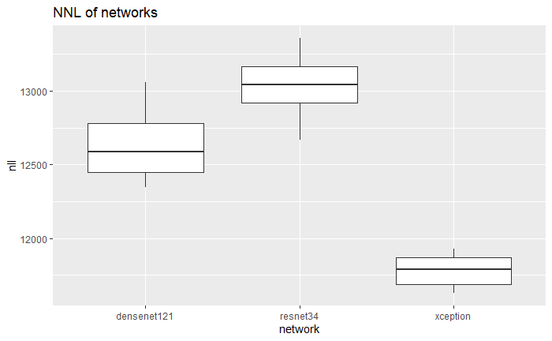

```r
box_net_nll <- ggplot() + geom_boxplot(data=net_results, mapping=aes(x=network, y=nll)) +
  ggtitle("NNL of networks")
box_net_nll
```

```r
ens_results_wide <- pivot_wider(ens_results, names_from = c(train_set, method), values_from = c(accuracy, nll))
ens_results_wide
```

| repli | fold | accuracy_tt_m1 | accuracy_tt_m2 | accuracy_tt_m2_iter | accuracy_tt_bc | accuracy_vt_m1 | accuracy_vt_m2 | accuracy_vt_m2_iter | accuracy_vt_bc | nll_tt_m1 | nll_tt_m2 | nll_tt_m2_iter | nll_tt_bc | nll_vt_m1 | nll_vt_m2 | nll_vt_m2_iter | nll_vt_bc |
| --- | --- | --- | --- | --- | --- | --- | --- | --- | --- | --- | --- | --- | --- | --- | --- | --- | --- |
| 0 | 0 | 0.7311 | 0.7313 | 0.7313 | 0.7306 | 0.7343 | 0.7322 | 0.7322 | 0.7233 | 35754.30 | 35260.70 | 35249.41 | 18516.97 | 9971.794 | 10243.94 | 10243.73 | 10616.41 |
| 0 | 1 | 0.7334 | 0.7333 | 0.7333 | 0.7325 | 0.7324 | 0.7274 | 0.7274 | 0.7197 | 35343.71 | 34850.68 | 34838.43 | 18493.15 | 10063.176 | 10368.74 | 10368.53 | 10599.88 |
| 0 | 2 | 0.7316 | 0.7317 | 0.7317 | 0.7313 | 0.7321 | 0.7287 | 0.7287 | 0.7258 | 35757.60 | 35301.74 | 35291.68 | 18504.37 | 10074.446 | 10376.39 | 10376.19 | 10437.34 |
| 0 | 3 | 0.7343 | 0.7341 | 0.7341 | 0.7335 | 0.7305 | 0.7269 | 0.7269 | 0.7256 | 35261.77 | 34820.77 | 34809.46 | 18479.91 | 10116.347 | 10407.83 | 10407.62 | 10520.96 |
| 0 | 4 | 0.7323 | 0.7322 | 0.7322 | 0.7306 | 0.7315 | 0.7297 | 0.7297 | 0.7218 | 35309.03 | 34752.21 | 34741.86 | 18460.82 | 10081.148 | 10364.60 | 10364.33 | 10440.81 |
| 1 | 0 | 0.7337 | 0.7335 | 0.7335 | 0.7333 | 0.7277 | 0.7259 | 0.7259 | 0.7192 | 35709.17 | 35109.85 | 35098.44 | 18573.41 | 10213.645 | 10471.30 | 10471.12 | 10769.21 |
| 1 | 1 | 0.7344 | 0.7348 | 0.7348 | 0.7344 | 0.7267 | 0.7243 | 0.7243 | 0.7154 | 35930.79 | 35197.54 | 35188.34 | 18584.75 | 10227.414 | 10519.73 | 10519.27 | 10838.00 |
| 1 | 2 | 0.7317 | 0.7319 | 0.7319 | 0.7315 | 0.7327 | 0.7292 | 0.7292 | 0.7216 | 35936.58 | 35344.21 | 35334.15 | 18573.81 | 10068.739 | 10323.71 | 10323.66 | 10645.25 |
| 1 | 3 | 0.7314 | 0.7313 | 0.7313 | 0.7319 | 0.7289 | 0.7260 | 0.7260 | 0.7169 | 35823.91 | 35201.62 | 35192.40 | 18594.95 | 10246.284 | 10515.56 | 10515.22 | 10694.30 |
| 1 | 4 | 0.7307 | 0.7305 | 0.7305 | 0.7308 | 0.7271 | 0.7237 | 0.7237 | 0.7187 | 36200.90 | 35605.39 | 35595.41 | 18600.83 | 10189.321 | 10437.33 | 10437.09 | 10753.57 |

[output cut: 40 more lines]

Testing statistical significance of difference for training on validation and train data. We have 50 samples from each distribution, so we will suppose the distributions are normal.

```r
t.test(ens_results_wide$accuracy_vt_m1, ens_results_wide$accuracy_tt_m1)
```

```
    Welch Two Sample t-test

data:  ens_results_wide$accuracy_vt_m1 and ens_results_wide$accuracy_tt_m1
t = -5.4347, df = 97.747, p-value = 4.03e-07
alternative hypothesis: true difference in means is not equal to 0
95 percent confidence interval:
 -0.003634047 -0.001689953
sample estimates:
mean of x mean of y
 0.730470  0.733132
```

```r
t.test(ens_results_wide$accuracy_vt_m1, ens_results_wide$accuracy_tt_m1, alternative="less")
```

```
    Welch Two Sample t-test

data:  ens_results_wide$accuracy_vt_m1 and ens_results_wide$accuracy_tt_m1
t = -5.4347, df = 97.747, p-value = 2.015e-07
alternative hypothesis: true difference in means is less than 0
95 percent confidence interval:
         -Inf -0.001848622
sample estimates:
mean of x mean of y
 0.730470  0.733132
```

```r
t.test(ens_results_wide$accuracy_vt_m2, ens_results_wide$accuracy_tt_m2)
```

```
    Welch Two Sample t-test

data:  ens_results_wide$accuracy_vt_m2 and ens_results_wide$accuracy_tt_m2
t = -10.184, df = 97.102, p-value < 2.2e-16
alternative hypothesis: true difference in means is not equal to 0
95 percent confidence interval:
 -0.006036541 -0.004067459
sample estimates:
mean of x mean of y
 0.728056  0.733108
```

```r
t.test(ens_results_wide$accuracy_vt_m2, ens_results_wide$accuracy_tt_m2, alternative="less")
```

```
    Welch Two Sample t-test

data:  ens_results_wide$accuracy_vt_m2 and ens_results_wide$accuracy_tt_m2
t = -10.184, df = 97.102, p-value < 2.2e-16
alternative hypothesis: true difference in means is less than 0
95 percent confidence interval:
         -Inf -0.004228184
sample estimates:
mean of x mean of y
 0.728056  0.733108
```

```r
t.test(ens_results_wide$accuracy_vt_m2_iter, ens_results_wide$accuracy_tt_m2_iter)
```

[output not shown]

```r
t.test(ens_results_wide$accuracy_vt_m2_iter, ens_results_wide$accuracy_tt_m2_iter, alternative="less")
```

[output not shown]

```r
t.test(ens_results_wide$accuracy_vt_bc, ens_results_wide$accuracy_tt_bc)
```

```
    Welch Two Sample t-test

data:  ens_results_wide$accuracy_vt_bc and ens_results_wide$accuracy_tt_bc
t = -20.679, df = 95.596, p-value < 2.2e-16
alternative hypothesis: true difference in means is not equal to 0
95 percent confidence interval:
 -0.0126412 -0.0104268
sample estimates:
mean of x mean of y
 0.721520  0.733054
```

```r
t.test(ens_results_wide$accuracy_vt_bc, ens_results_wide$accuracy_tt_bc, alternative="less")
```

```
    Welch Two Sample t-test

data:  ens_results_wide$accuracy_vt_bc and ens_results_wide$accuracy_tt_bc
t = -20.679, df = 95.596, p-value < 2.2e-16
alternative hypothesis: true difference in means is less than 0
95 percent confidence interval:
        -Inf -0.01060759
sample estimates:
mean of x mean of y
 0.721520  0.733054
```

Outputs of each coupling method has statistically higher accuracy when LDA is trained on training set of neural networks.